```python
import pandas as pd
import numpy as np
import os
import requests
import json
import bs4

from IPython.display import display, Image
```

# Lecture 16 – More Parsing Examples

## DSC 80, Spring 2023

### Agenda

- Parsing HTML using Beautiful Soup.
  - Example: Scraping the HDSI Faculty page.
  - Example: Scraping quotes.
- Nested vs. flat data structures.

## Parsing HTML using Beautiful Soup

### `BeautifulSoup` objects

- `bs4.BeautifulSoup` takes in a string or file-like object representing HTML (markup) and returns a **parsed** document.
- Remember, HTML documents are represented as **trees**, under the "Document Object Model."

```python
html_string = '''
<html>
    <body>
      <div id="content">
        <h1>Heading here</h1>
        <p>My First paragraph</p>
        <p>My <em>second</em> paragraph</p>
        <hr>
      </div>
      <div id="nav">
        <ul>
          <li>item 1</li>
          <li>item 2</li>
          <li>item 3</li>
        </ul>
      </div>
    </body>
</html>
'''.strip()
```

```python
soup = bs4.BeautifulSoup(html_string)
```

```python
type(soup)
```

```
bs4.BeautifulSoup
```

### Finding elements in a tree

The most common methods you'll use to find *tags* in a `soup` object are:

- `soup.find(tag)`, which finds the **first** instance of a tag (the first one on the page, i.e. the first one that DFS sees).
  - More general: `soup.find(name=None, attrs={}, recursive=True, text=None, **kwargs)`.
- `soup.find_all(tag)`, which finds **all** instances of a tag.

### Using `find_all`

`find_all` returns a list of all matches.

```python
soup.find_all('div')
```

```
[<div id="content">
 <h1>Heading here</h1>
 <p>My First paragraph</p>
 <p>My <em>second</em> paragraph</p>
 <hr/>
 </div>,
 <div id="nav">
 <ul>
 <li>item 1</li>
 <li>item 2</li>
 <li>item 3</li>
 </ul>
 </div>]
```

```python
soup.find_all('li')
```

```
[<li>item 1</li>, <li>item 2</li>, <li>item 3</li>]
```

```python
[x.text for x in soup.find_all('li')]
```

```
['item 1', 'item 2', 'item 3']
```

### Node attributes

- The `text` attribute of a tag element gets the text between the opening and closing tags.
- The `attrs` attribute lists all attributes of a tag.
- The `get(key)` method gets the value of a tag attribute.

```python
soup.find('p')
```

```
<p>My First paragraph</p>
```

```python
soup.find('p').text
```

```
'My First paragraph'
```

```python
soup.find('div')
```

```
<div id="content">
<h1>Heading here</h1>
<p>My First paragraph</p>
<p>My <em>second</em> paragraph</p>
<hr/>
</div>
```

```python
soup.find('div').attrs
```

```
{'id': 'content'}
```

```python
soup.find('div').get('id')
```

```
'content'
```

The `get` method must be called directly on the node that contains the attribute you're looking for.

```python
soup
```

```
<html>
<body>
<div id="content">
<h1>Heading here</h1>
<p>My First paragraph</p>
<p>My <em>second</em> paragraph</p>
<hr/>
</div>
<div id="nav">
<ul>
<li>item 1</li>
<li>item 2</li>
<li>item 3</li>
</ul>
</div>
</body>
</html>
```

```python
# While there are multiple 'id' attributes, none of them are in the <html> tag at the top.
soup.get('id')
```

```python
soup.find('div').get('id')
```

```
'content'
```

## Example: Scraping the HDSI Faculty page

### Example

Let's try and extract a list of HDSI Faculty from https://datascience.ucsd.edu/about/faculty/faculty/.

A good first step is to use the "inspect element" tool in our web browser.

```python
fac_response = requests.get('https://datascience.ucsd.edu/faculty/')
fac_response
```

```
<Response [200]>
```

```python
soup = bs4.BeautifulSoup(fac_response.text)
```

```python
divs = soup.find_all('div', attrs={'class': 'vc_custom_heading vc_gitem-post-data vc_gitem-post-data-source-post_title'})
```

```python
divs[0]
```

```
<div class="vc_custom_heading vc_gitem-post-data vc_gitem-post-data-source-post_title">
<h4 style="text-align: left"><a href="https://www-physics.ucsd.edu/Directory/Person/1" target="_blank">Henry Abarbanel</a></h4>
</div>
```

Within here, we need to extract each faculty member's name. It seems like names are stored as text within the `<a>` tag.

```python
divs[0].find('a').text
```

```
'Henry Abarbanel'
```

We can also extract job titles:

```python
divs1 = soup.find_all('div', attrs={'class': 'vc_gitem-align-left fields'})

divs1[0]
```

```
<div class="vc_gitem-align-left fields">
<div class="field pendari_people_title">Distinguished Professor</div>
</div>
```

```python
divs1 = soup.find_all('div', attrs={'class': 'field pendari_people_title'})

divs1[0].text
```

```
'Distinguished Professor'
```

Let's create a DataFrame consisting of names and job titles for each faculty member.

```python
names = [div.find('a').text for div in divs]
names
```

```
['Henry Abarbanel',
 'Ilkay Altintas',
 'Tiffany Amariuta',
 'Mikio Aoi',
 'Ery Arias-Castro',
 'Vineet Bafna',
 'Mikhail Belkin',
 'Jelena Bradic',
 'Henrik Christensen',
 'Alex Cloninger',
 'Anders Dale',
 'David Danks',
 'Virginia de Sa',
 'Justin Eldridge',
 'Shannon Ellis',
 'Yoav Freund',
 'R Stuart Geiger',
 'Nigel Goldenfeld',
 'Rajesh Gupta',
 'Mike Holst',
 'Albert Hsiao',
 'Zhiting Hu',
 'Biwei Huang',
 'Tara Javidi',
 'Haojian Jin',
 'Young-Han Kim',
 'Rob Knight',
 'Arun Kumar',
 'Marina Langlois',
 'Soohyun Nam Liao',
 'Yian Ma',
 'Arya Mazumdar',
 'Julian McAuley',
 'Gal Mishne',
 'Eran Mukamel',
 'Dimitris Politis',
 'Georgio Quer',
 'Tauhidur Rahman',
 'Suraj Rampure',
 'Margaret “Molly” Roberts',
 'Rayan Saab',
 'Barna Saha',
 'Babak Salimi',
 'Armin Schwartzman',
 'Terrence ‘Terry’ Sejnowski',
 'Jingbo Shang',
 'Jack Silberman',
 'Benjamin Smarr',
 'Shankar Subramaniam',
 'George Sugihara',
 'Janine Tiefenbruck',
 'Berk Ustun',
 'Bradley Voytek',
 'Yusu Wang',
 'Duncan Watson-Parris',
 'Lily Weng',
 'Frank Wuerthwein',
 'Ronghui (Lily) Xu',
 'Rose Yu',
 'Hao Zhang',
 'Yuhua Zhu']
```

```python
# titles = []
# for div in divs:
#     h4 = div.find('h4')
#     if h4:
#         titles.append(h4.text)
#     else:
#         titles.append('')

titles = [div.text for div in divs1]
titles
```

```
['Distinguished Professor',
 'SDSC Chief Data Science Officer & HDSI Founding Faculty Fellow',
 'Assistant Professor',
 'Assistant Professor',
 'Professor',
 'Professor',
 'Professor',
 'Professor',
 'Distinguished Scientist, Professor',
 'Associate Professor',
 'Distinguished Scientist, Professor',
 'Professor',
 'Professor, HDSI Associate Director',
 'Assistant Teaching Professor',
 'Associate Teaching Professor',
 'Professor',
 'Assistant Professor',
 'Distinguished Professor',
 'Distinguished Professor, HDSI Founding Director',
 'Professor',
 'Associate Professor',
 'Assistant Professor',
 'Assistant Professor',
 'Professor & HDSI Founding Faculty Fellow',
 'Assistant Professor',
 'Professor',
 'Professor',
 'Associate Professor, HDSI Faculty Fellow',
 'Lecturer',
 'Assistant Teaching Professor',
 'Assistant Professor',
 'Associate Professor',
 'Professor',
 'Assistant Professor',
 'Associate Professor',
 'Distinguished Professor, HDSI Associate Director',
 'Lecturer',
 'Assistant Professor',
 'Lecturer',
 'Professor',
 'Associate Professor',
 'Associate Professor',
 'Assistant Professor',
 'Professor',
 'Distinguished Professor',
 'Assistant Professor',
 'Lecturer',
 'Assistant Professor',
 'Distinguished Professor',
 'Distinguished Professor',
 'Lecturer',
 'Assistant Professor',
 'Professor & HDSI Founding Faculty Fellow',
 'Professor',
 'Assistant Professor',
 'Assistant Professor',
 'Professor/ Director of SDSC',
 'Professor',
 'Assistant Professor',
 'Assistant Professor',
 'Assistant Professor']
```

```python
faculty = pd.DataFrame().assign(name=names, title=titles)
faculty.head()
```

|  | name | title |
| --- | --- | --- |
| 0 | Henry Abarbanel | Distinguished Professor |
| 1 | Ilkay Altintas | SDSC Chief Data Science Officer & HDSI Foundin... |
| 2 | Tiffany Amariuta | Assistant Professor |
| 3 | Mikio Aoi | Assistant Professor |
| 4 | Ery Arias-Castro | Professor |

Now we have a DataFrame!

```python
faculty[faculty['title'] == 'Professor']
```

|  | name | title |
| --- | --- | --- |
| 4 | Ery Arias-Castro | Professor |
| 5 | Vineet Bafna | Professor |
| 6 | Mikhail Belkin | Professor |
| 7 | Jelena Bradic | Professor |
| 11 | David Danks | Professor |
| 15 | Yoav Freund | Professor |
| 19 | Mike Holst | Professor |
| 25 | Young-Han Kim | Professor |
| 26 | Rob Knight | Professor |
| 32 | Julian McAuley | Professor |
| 39 | Margaret “Molly” Roberts | Professor |
| 43 | Armin Schwartzman | Professor |
| 53 | Yusu Wang | Professor |
| 57 | Ronghui (Lily) Xu | Professor |

What if we want to get faculty members' pictures? It seems like we should look at the attributes of an `<img>` tag.

```python
def show_picture(name):
    idx = names.index(name)
    imgs = soup.find_all('img', attrs={'class': 'vc_gitem-zone-img'})
    url = imgs[idx].get('src')
    display(Image(url))
```

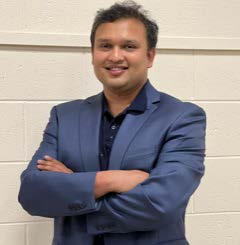

```python
show_picture('Tauhidur Rahman')
```

## Example: Scraping quotes

### Example: Scraping quotes

Let's scrape quotes from https://quotes.toscrape.com/.

[figure not shown]

Specifically, let's try to make a DataFrame that looks like the one below:

|  | quote | author | author_url | tags |
| --- | --- | --- | --- | --- |
| 0 | “The world as we have created it is a process of our thinking. It cannot be changed without changing our thinking.” | Albert Einstein | https://quotes.toscrape.com/author/Albert-Einstein | change,deep-thoughts,thinking,world |
| 1 | “It is our choices, Harry, that show what we truly are, far more than our abilities.” | J.K. Rowling | https://quotes.toscrape.com/author/J-K-Rowling | abilities,choices |
| 2 | “There are only two ways to live your life. One is as though nothing is a miracle. The other is as though everything is a miracle.” | Albert Einstein | https://quotes.toscrape.com/author/Albert-Einstein | inspirational,life,live,miracle,miracles |

### The plan

Eventually, we will create a single function – `quote_df` – which takes in an integer `n` and returns a **DataFrame** with the quotes on the **first `n` pages** of https://quotes.toscrape.com/.

To do this, we will define several helper functions:

- `download_page(i)`, which downloads a **single page** (page `i`) and returns a `BeautifulSoup` object of the response.
- `process_quote(div)`, which takes in a `<div>` tree corresponding to a **single quote** and returns a Series containing all of the relevant information for that quote.
- `process_page(divs)`, which takes in a list of `<div>` trees corresponding to a **single page** and returns a DataFrame containing all of the relevant information for all quotes on that page.

Key principle: some of our helper functions will make **requests**, and others will **parse**, but none will do both!

- Easier to debug and catch errors.
- Avoids unnecessary requests.

### Downloading a single page

```python
def download_page(i):
    url = f'https://quotes.toscrape.com/page/{i}'
    request = requests.get(url)
    return bs4.BeautifulSoup(request.text)
```

In `quote_df`, we will call `download_page` repeatedly – once for `i=1`, once for `i=2`, ..., `i = n`. For now, we will work with just page 5 (chosen arbitrarily).

```python
soup = download_page(5)
```

### Parsing a single page

Let's look at the page's source code (via "inspect element") to find where the quotes in the page are located.

```python
divs = soup.find_all('div', attrs={'class': 'quote'})
```

```python
divs[0]
```

```
<div class="quote" itemscope="" itemtype="http://schema.org/CreativeWork">
<span class="text" itemprop="text">“A reader lives a thousand lives before he dies, said Jojen. The man who never reads lives only one.”</span>
<span>by <small class="author" itemprop="author">George R.R. Martin</small>
<a href="/author/George-R-R-Martin">(about)</a>
</span>
<div class="tags">
            Tags:
            <meta class="keywords" content="read,readers,reading,reading-books" itemprop="keywords"/>
<a class="tag" href="/tag/read/page/1/">read</a>
<a class="tag" href="/tag/readers/page/1/">readers</a>
<a class="tag" href="/tag/reading/page/1/">reading</a>
<a class="tag" href="/tag/reading-books/page/1/">reading-books</a>
</div>
</div>
```

From this `<div>`, we can extract the quote, author name, author's URL, and tags.

```python
divs[0].find('span', attrs={'class': 'text'}).text
```

```
'“A reader lives a thousand lives before he dies, said Jojen. The man who never reads lives only one.”'
```

```python
divs[0].find('small', attrs={'class': 'author'}).text
```

```
'George R.R. Martin'
```

```python
divs[0].find('a').get('href')
```

```
'/author/George-R-R-Martin'
```

```python
divs[0].find('meta', attrs={'class': 'keywords'}).get('content')
```

```
'read,readers,reading,reading-books'
```

Let's implement our next function, `process_quote`, which takes in a `<div>` corresponding to a single quote and returns a **Series** containing the quote's information.

Note that this approach is different than the approach taken in the HDSI Faculty page example – there, we created each column of our final DataFrame separately, while here we are creating one **row** of our final DataFrame at a time.

```python
def process_quote(div):
    quote = div.find('span', attrs={'class': 'text'}).text
    author = div.find('small', attrs={'class': 'author'}).text
    author_url = 'https://quotes.toscrape.com' + div.find('a').get('href')
    tags = div.find('meta', attrs={'class': 'keywords'}).get('content')

    return pd.Series({'quote': quote, 'author': author, 'author_url': author_url, 'tags': tags})
```

```python
process_quote(divs[3])
```

```
quote         “If you can make a woman laugh, you can make h...
author                                           Marilyn Monroe
author_url    https://quotes.toscrape.com/author/Marilyn-Monroe
tags                                                 girls,love
dtype: object
```

Our last helper function will take in a **list** of `<div>`s, call `process_quote` on each `<div>` in the list, and return a **DataFrame**.

```python
def process_page(divs):
    return pd.DataFrame([process_quote(div) for div in divs])
```

```python
process_page(divs)
```

|  | quote | author | author_url | tags |
| --- | --- | --- | --- | --- |
| 0 | “A reader lives a thousand lives before he die... | George R.R. Martin | https://quotes.toscrape.com/author/George-R-R-... | read,readers,reading,reading-books |
| 1 | “You can never get a cup of tea large enough o... | C.S. Lewis | https://quotes.toscrape.com/author/C-S-Lewis | books,inspirational,reading,tea |
| 2 | “You believe lies so you eventually learn to t... | Marilyn Monroe | https://quotes.toscrape.com/author/Marilyn-Monroe |  |
| 3 | “If you can make a woman laugh, you can make h... | Marilyn Monroe | https://quotes.toscrape.com/author/Marilyn-Monroe | girls,love |
| 4 | “Life is like riding a bicycle. To keep your b... | Albert Einstein | https://quotes.toscrape.com/author/Albert-Eins... | life,simile |
| 5 | “The real lover is the man who can thrill you ... | Marilyn Monroe | https://quotes.toscrape.com/author/Marilyn-Monroe | love |
| 6 | “A wise girl kisses but doesn't love, listens ... | Marilyn Monroe | https://quotes.toscrape.com/author/Marilyn-Monroe | attributed-no-source |
| 7 | “Only in the darkness can you see the stars.” | Martin Luther King Jr. | https://quotes.toscrape.com/author/Martin-Luth... | hope,inspirational |
| 8 | “It matters not what someone is born, but what... | J.K. Rowling | https://quotes.toscrape.com/author/J-K-Rowling | dumbledore |
| 9 | “Love does not begin and end the way we seem t... | James Baldwin | https://quotes.toscrape.com/author/James-Baldwin | love |

### Putting it all together

```python
def quote_df(n):
    '''Returns a DataFrame containing the quotes on the first n pages of https://quotes.toscrape.com/.'''
    dfs = []
    for i in range(1, n + 1):
        # Download page n and create a BeautifulSoup object.
        soup = download_page(i)

        # Create DataFrame using the information in that page.
        divs = soup.find_all('div', attrs={'class': 'quote'})
        df = process_page(divs)

        # Append DataFrame to dfs.
        dfs.append(df)

    # Stitch all DataFrames together.
    return pd.concat(dfs).reset_index(drop=True)
```

```python
first_three_pages = quote_df(3)
first_three_pages.head()
```

|  | quote | author | author_url | tags |
| --- | --- | --- | --- | --- |
| 0 | “The world as we have created it is a process ... | Albert Einstein | https://quotes.toscrape.com/author/Albert-Eins... | change,deep-thoughts,thinking,world |
| 1 | “It is our choices, Harry, that show what we t... | J.K. Rowling | https://quotes.toscrape.com/author/J-K-Rowling | abilities,choices |
| 2 | “There are only two ways to live your life. On... | Albert Einstein | https://quotes.toscrape.com/author/Albert-Eins... | inspirational,life,live,miracle,miracles |
| 3 | “The person, be it gentleman or lady, who has ... | Jane Austen | https://quotes.toscrape.com/author/Jane-Austen | aliteracy,books,classic,humor |
| 4 | “Imperfection is beauty, madness is genius and... | Marilyn Monroe | https://quotes.toscrape.com/author/Marilyn-Monroe | be-yourself,inspirational |

The elements in the `'tags'` column are all strings, but they look like lists. This is not ideal, as we will see shortly.

### Key takeaways

- Make as few requests as possible.
- Create a request and parsing plan **beforehand**.
- Create your output schema **beforehand**.
- Make requests and parse in **separate functions**!
- See Lab 6, Question 2 for a related example.

## Nested vs. flat data formats

### Nested vs. flat data formats

- **Nested** data formats, like HTML, JSON, and XML, allow us to represent hierarchical relationships between variables.
- **Flat** (i.e. tabular) data formats, like CSV, do not.

[figure not shown]

### Aside: JSON Crack

The site [jsoncrack.com](https://jsoncrack.com/editor) allows you to upload a JSON file and visualizes it. Let's try it with `data/family.json`!

### Example: Scraping quotes, again

- Suppose we obtained the quotes data via an API and saved it to the file `data/quotes2scrape.json`.
- `quotes2scrape.json` is a **JSON records** file; each line is a valid JSON object, **but the entire document is not**.

```python
f = open(os.path.join('data', 'quotes2scrape.json'))
```

```python
json.loads(f.readline())
```

```
{'auth_url': 'http://quotes.toscrape.com/author/Albert-Einstein',
 'quote_auth': 'Albert Einstein',
 'quote_text': '“The world as we have created it is a process of our thinking. It cannot be changed without changing our thinking.”',
 'bio': 'In 1879, Albert Einstein was born in Ulm, Germany. He completed his Ph.D. at the University of Zurich by 1909. His 1905 paper explaining the photoelectric effect, the basis of electronics, earned him the Nobel Prize in 1921. His first paper on Special Relativity Theory, also published in 19…
 'dob': 'March 14, 1879',
 'tags': ['change', 'deep-thoughts', 'thinking', 'world']}
```

Note that for a single quote, we have keys for `'auth_url'`, `'quote_auth'`, `'quote_text'`, `'bio'`, `'dob'`, and `'tags'`.

Since each line is a separate JSON object, let's read in each line one at a time.

```python
L = [json.loads(x) for x in open(os.path.join('data', 'quotes2scrape.json'))]
```

Let's convert the result to a DataFrame.

```python
df = pd.DataFrame(L)
df.head()
```

|  | auth_url | quote_auth | quote_text | bio | dob | tags |
| --- | --- | --- | --- | --- | --- | --- |
| 0 | http://quotes.toscrape.com/author/Albert-Einstein | Albert Einstein | “The world as we have created it is a process ... | In 1879, Albert Einstein was born in Ulm, Germ... | March 14, 1879 | [change, deep-thoughts, thinking, world] |
| 1 | http://quotes.toscrape.com/author/J-K-Rowling | J.K. Rowling | “It is our choices, Harry, that show what we t... | See also: Robert GalbraithAlthough she writes ... | July 31, 1965 | [abilities, choices] |
| 2 | http://quotes.toscrape.com/author/Albert-Einstein | Albert Einstein | “There are only two ways to live your life. On... | In 1879, Albert Einstein was born in Ulm, Germ... | March 14, 1879 | [inspirational, life, live, miracle, miracles] |
| 3 | http://quotes.toscrape.com/author/Jane-Austen | Jane Austen | “The person, be it gentleman or lady, who has ... | Jane Austen was an English novelist whose work... | December 16, 1775 | [aliteracy, books, classic, humor] |
| 4 | http://quotes.toscrape.com/author/Marilyn-Monroe | Marilyn Monroe | “Imperfection is beauty, madness is genius and... | Marilyn Monroe (born Norma Jeane Mortenson; Ju... | June 01, 1926 | [be-yourself, inspirational] |

What data type is the `'tags'` column?

```python
df['tags'].iloc[0]
```

```
['change', 'deep-thoughts', 'thinking', 'world']
```

Let's save `df` to a CSV and read it back in.

```python
df.to_csv('out.csv')
```

```python
df_again = pd.read_csv('out.csv')
df_again.head()
```

|  | Unnamed: 0 | auth_url | quote_auth | quote_text | bio | dob | tags |
| --- | --- | --- | --- | --- | --- | --- | --- |
| 0 | 0 | http://quotes.toscrape.com/author/Albert-Einstein | Albert Einstein | “The world as we have created it is a process ... | In 1879, Albert Einstein was born in Ulm, Germ... | March 14, 1879 | ['change', 'deep-thoughts', 'thinking', 'world'] |
| 1 | 1 | http://quotes.toscrape.com/author/J-K-Rowling | J.K. Rowling | “It is our choices, Harry, that show what we t... | See also: Robert GalbraithAlthough she writes ... | July 31, 1965 | ['abilities', 'choices'] |
| 2 | 2 | http://quotes.toscrape.com/author/Albert-Einstein | Albert Einstein | “There are only two ways to live your life. On... | In 1879, Albert Einstein was born in Ulm, Germ... | March 14, 1879 | ['inspirational', 'life', 'live', 'miracle', '... |
| 3 | 3 | http://quotes.toscrape.com/author/Jane-Austen | Jane Austen | “The person, be it gentleman or lady, who has ... | Jane Austen was an English novelist whose work... | December 16, 1775 | ['aliteracy', 'books', 'classic', 'humor'] |
| 4 | 4 | http://quotes.toscrape.com/author/Marilyn-Monroe | Marilyn Monroe | “Imperfection is beauty, madness is genius and... | Marilyn Monroe (born Norma Jeane Mortenson; Ju... | June 01, 1926 | ['be-yourself', 'inspirational'] |

What data type is the `'tags'` column now?

```python
df_again['tags'].iloc[0]
```

```
"['change', 'deep-thoughts', 'thinking', 'world']"
```

### One-hot encoding

- So that we don't have to deal with lists within Series, we can **flatten** lists of tags so that there is **one column per unique tag**.
  - For example, consider the tag `'inspirational'`.
  - If a quote has a 1 in the `'inspirational'` column, it **was** tagged `'inspirational'`.
  - If a quote has a 0 in the `'inspirational'` column, it **was not** tagged `'inspirational'`.
- This process – of converting categorical variables into columns of 1s and 0s – is called **one-hot encoding**. We will revisit it in a few weeks.

Let's write a function that takes in the list of tags (`taglist`) for a given quote and returns the one-hot-encoded sequence of 1s and 0s for that quote.

```python
taglist
```

[output not shown]

```python
def flatten_tags(taglist):
    return pd.Series({k:1 for k in taglist}, dtype=float)

tags = df['tags'].apply(flatten_tags).fillna(0).astype(int)
tags.head()
```

|  | change | deep-thoughts | thinking | world | abilities | choices | inspirational | life | live | miracle | ... | christianity | faith | sun | adventure | better-life-empathy | difficult | grown-ups | write | writers | mind |
| --- | --- | --- | --- | --- | --- | --- | --- | --- | --- | --- | --- | --- | --- | --- | --- | --- | --- | --- | --- | --- | --- |
| 0 | 1 | 1 | 1 | 1 | 0 | 0 | 0 | 0 | 0 | 0 | ... | 0 | 0 | 0 | 0 | 0 | 0 | 0 | 0 | 0 | 0 |
| 1 | 0 | 0 | 0 | 0 | 1 | 1 | 0 | 0 | 0 | 0 | ... | 0 | 0 | 0 | 0 | 0 | 0 | 0 | 0 | 0 | 0 |
| 2 | 0 | 0 | 0 | 0 | 0 | 0 | 1 | 1 | 1 | 1 | ... | 0 | 0 | 0 | 0 | 0 | 0 | 0 | 0 | 0 | 0 |
| 3 | 0 | 0 | 0 | 0 | 0 | 0 | 0 | 0 | 0 | 0 | ... | 0 | 0 | 0 | 0 | 0 | 0 | 0 | 0 | 0 | 0 |
| 4 | 0 | 0 | 0 | 0 | 0 | 0 | 1 | 0 | 0 | 0 | ... | 0 | 0 | 0 | 0 | 0 | 0 | 0 | 0 | 0 | 0 |

5 rows × 137 columns

Let's combine this one-hot-encoded DataFrame with `df`.

```python
df_full = pd.concat([df, tags], axis=1).drop(columns='tags')
df_full.head()
```

|  | auth_url | quote_auth | quote_text | bio | dob | change | deep-thoughts | thinking | world | abilities | ... | christianity | faith | sun | adventure | better-life-empathy | difficult | grown-ups | write | writers | mind |
| --- | --- | --- | --- | --- | --- | --- | --- | --- | --- | --- | --- | --- | --- | --- | --- | --- | --- | --- | --- | --- | --- |
| 0 | http://quotes.toscrape.com/author/Albert-Einstein | Albert Einstein | “The world as we have created it is a process ... | In 1879, Albert Einstein was born in Ulm, Germ... | March 14, 1879 | 1 | 1 | 1 | 1 | 0 | ... | 0 | 0 | 0 | 0 | 0 | 0 | 0 | 0 | 0 | 0 |
| 1 | http://quotes.toscrape.com/author/J-K-Rowling | J.K. Rowling | “It is our choices, Harry, that show what we t... | See also: Robert GalbraithAlthough she writes ... | July 31, 1965 | 0 | 0 | 0 | 0 | 1 | ... | 0 | 0 | 0 | 0 | 0 | 0 | 0 | 0 | 0 | 0 |
| 2 | http://quotes.toscrape.com/author/Albert-Einstein | Albert Einstein | “There are only two ways to live your life. On... | In 1879, Albert Einstein was born in Ulm, Germ... | March 14, 1879 | 0 | 0 | 0 | 0 | 0 | ... | 0 | 0 | 0 | 0 | 0 | 0 | 0 | 0 | 0 | 0 |
| 3 | http://quotes.toscrape.com/author/Jane-Austen | Jane Austen | “The person, be it gentleman or lady, who has ... | Jane Austen was an English novelist whose work... | December 16, 1775 | 0 | 0 | 0 | 0 | 0 | ... | 0 | 0 | 0 | 0 | 0 | 0 | 0 | 0 | 0 | 0 |
| 4 | http://quotes.toscrape.com/author/Marilyn-Monroe | Marilyn Monroe | “Imperfection is beauty, madness is genius and... | Marilyn Monroe (born Norma Jeane Mortenson; Ju... | June 01, 1926 | 0 | 0 | 0 | 0 | 0 | ... | 0 | 0 | 0 | 0 | 0 | 0 | 0 | 0 | 0 | 0 |

5 rows × 142 columns

If we want all quotes tagged `'inspiration'`, we can simply query:

```python
df_full[df_full['inspirational'] == 1].head()
```

|  | auth_url | quote_auth | quote_text | bio | dob | change | deep-thoughts | thinking | world | abilities | ... | christianity | faith | sun | adventure | better-life-empathy | difficult | grown-ups | write | writers | mind |
| --- | --- | --- | --- | --- | --- | --- | --- | --- | --- | --- | --- | --- | --- | --- | --- | --- | --- | --- | --- | --- | --- |
| 2 | http://quotes.toscrape.com/author/Albert-Einstein | Albert Einstein | “There are only two ways to live your life. On... | In 1879, Albert Einstein was born in Ulm, Germ... | March 14, 1879 | 0 | 0 | 0 | 0 | 0 | ... | 0 | 0 | 0 | 0 | 0 | 0 | 0 | 0 | 0 | 0 |
| 4 | http://quotes.toscrape.com/author/Marilyn-Monroe | Marilyn Monroe | “Imperfection is beauty, madness is genius and... | Marilyn Monroe (born Norma Jeane Mortenson; Ju... | June 01, 1926 | 0 | 0 | 0 | 0 | 0 | ... | 0 | 0 | 0 | 0 | 0 | 0 | 0 | 0 | 0 | 0 |
| 7 | http://quotes.toscrape.com/author/Thomas-A-Edison | Thomas A. Edison | “I have not failed. I've just found 10,000 way... | Thomas Alva Edison was an American inventor, s... | February 11, 1847 | 0 | 0 | 0 | 0 | 0 | ... | 0 | 0 | 0 | 0 | 0 | 0 | 0 | 0 | 0 | 0 |
| 10 | http://quotes.toscrape.com/author/Marilyn-Monroe | Marilyn Monroe | “This life is what you make it. No matter what... | Marilyn Monroe (born Norma Jeane Mortenson; Ju... | June 01, 1926 | 0 | 0 | 0 | 0 | 0 | ... | 0 | 0 | 0 | 0 | 0 | 0 | 0 | 0 | 0 | 0 |
| 16 | http://quotes.toscrape.com/author/Elie-Wiesel | Elie Wiesel | “The opposite of love is not hate, it's indiff... | Eliezer Wiesel was a Romania-born American nov... | September 30, 1928 | 0 | 0 | 0 | 0 | 0 | ... | 0 | 0 | 0 | 0 | 0 | 0 | 0 | 0 | 0 | 0 |

5 rows × 142 columns

Note that this DataFrame representation of the response JSON takes up much more space than the original JSON. Why is that?

## Summary, next time

### Summary

- Beautiful Soup is an HTML parser that allows us to (somewhat) easily extract information from HTML documents.
  - `soup.find` and `soup.find_all` are the functions you will use most often.
- When writing scraping code:
  - Use "inspect element" to identify the names of tags and attributes that are relevant to the information you want to extract.
  - Separate your logic for making requests and for parsing.

### Next time

All about regular expressions!